# S4 Opinión sobre igualdad de oportunidades según sexo

24-11-2022

# Introducción

### Relevancia

En la igualdad de género se busca la equidad en todos los rubros sociales tanto para varones como mujeres, además de promover las mismas oportunidades entre ellos. Generando una sociedad más homogénea para las futuras generaciones.

### Planificación

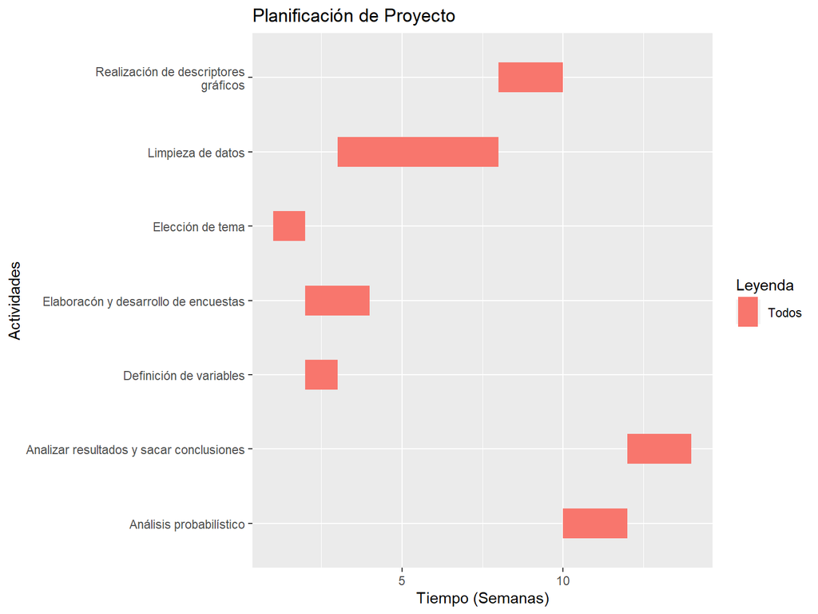

```r
library(ggplot2)
data <- data.frame(name = c('Elección de tema','Definición de variables',
'Elaboracón y desarrollo de encuestas', 'Limpieza de datos', 'Realización de descriptores
gráficos', 'Analizar resultados y sacar conclusiones', 'Análisis probabilístico'),
start = c(1, 2, 2, 3,8, 12,10),
end = c(2, 3, 4, 8, 10, 14,12),
Leyenda = c('Todos'))

ggplot(data, aes(x=start, xend=end, y=name, yend=name, color=Leyenda)) +
  theme_grey()+
  geom_segment(linewidth=10) +
  labs(title='Planificación de Proyecto', x='Tiempo (Semanas)', y='Actividades')
```

# Datos

### Proceso de recolección de datos

Los datos serán obtenidos mediante encuestas a personas limeñas. Se utilizó la encuesta, porque el tema pide la opinión pública para saber los distintos puntos de vista, como diferentes perspectivas y condiciones de cada encuestado, a diferencia que si se hubiese realizado mediante los grupos focales, no nos brindaría lo que queremos buscar.

Requisitos para la encuesta:

Visitar las universidades e institutos en los diferentes distritos de Lima.

### Poblacion

Los ciudadanos del distrito de Barranco entre hombres y mujeres que hayan culminado la educación secundaria.

### Muestra

Se obtuvieron 152 encuestas. 78 del sexo masculino y 74 sel sexo femenino

### Muestreo

Muestreo por conglomerados, ya que en base a un muestreo aleatorio simple, separamos en conglomerados por su grado de instrucción.

### Variables

- ¿Cuántos años tiene? Variable: `“Edad”`
- ¿Cuál es su grado de instrucción? Variable: `“Instruccion”`
- ¿Cree usted que hay más ventajas de ser hombre, o más ventajas de ser mujer, o no hay diferencia? Variable: `‘Preferenciagénero’`
- ¿ En qué medida, si acaso, piensa usted que las mujeres jóvenes en Perú habrán vivido mejor o peor que la generación de sus padres, o habrán sido igual? 1. Mejor 2. Más o menos 3. Peor Variable: `‘Estilovida’` A las siguientes preguntas responder una de las tres opciones: 1) Desacuerdo 2) Ni de acuerdo ni en desacuerdo 3) De acuerdo
- “Un hombre que se queda en casa para cuidar a los niños es menos hombre? Variable: `‘Hombrecuidahijos’`
- “Yo me sentiría incómodo si mi jefe fuera mujer” Variable: `“Jefemujer”`
- “Las mujeres no lograrán la igualdad en Perú a menos que los hombres también tomen acciones para apoyar los derechos de la mujer” Variable: `“MujeresSinIgualdad”` A las siguientes preguntas responder una de las cuatro opciones: 1) Se apoya demasiado 2) Se apoya lo necesario 3) Se apoya poco 4) No se apoya
- “Cuidado de los niños y del hogar” Variable: `“Cuidaninos”`
- “En los negocios“ Variable: `“igualnegocio”`
- “En el deporte” Variable: `“igualdeporte”`
- “En los medios de comunicación, incluso la televisión” variable: `“igualtelecomunicaciones”`
- “En las ciencias” Variable: `“igualciencias”`
- “En la educación” Variable: `“igualeducación”`

### Limpieza de base de datos

Cambiamos el nombre de las variables

```r
library(readr)
library(dplyr)
DF <- read_csv("BasedeDatosProyectoEyP.csv",
    col_types = cols(`Edad (años)` = col_number(),
        `Ingreso mensual (en soles) OPCIONAL` = col_number()))
rename(DF, Edad = 'Edad (años)', Ingresos = 'Ingreso mensual (en soles) OPCIONAL',
       Instruccion = 'Grado de instrucción',
       PreferenciaSexo = '¿Cree usted que hay más ventajas de ser hombre, o más ventajas de ser mujer, o no hay diferencia?',
       EstiloVida='¿Piensa usted que las mujeres jóvenes en Perú viven mejor, igual o peor que la generación de sus padres? 1. Mejor 2. Igual 3. Peor',
       HombrecuidaHijos='Un hombre que se queda en casa para cuidar a los niños es menos hombre',
       JefeMujer ="Me sentiría incómodo si mi jefe fuera mujer",
       MujerSinIgualdad="Las mujeres no lograrán la igualdad en Perú a menos que los hombres también tomen acciones para apoyar los derechos de la mujer",
       Cuidaninos="Cuidado de los niños y del hogar",
       igualnegocio = "“En los negocios“" ,
       igualdeporte = "En el deporte",
       igualtelecomunicaciones = "En los medios de comunicación, incluso la televisión",
       igualciencias = "En las ciencias",
       igualeducacion = "En la educación") -> Data2
DataFinal<- Data2[,-1]
DataFinal
```

```
## # A tibble: 152 x 15
##     Edad Ingresos Sexo   Instruccion PreferenciaSexo EstiloVida HombrecuidaHijos
##    <dbl>    <dbl> <chr>  <chr>       <chr>           <chr>      <chr>
##  1    18      900 Femen~ Superior u~ Más ventajas s~ Mejor      Desacuerdo
##  2    18     1000 Mascu~ Superior u~ No hay diferen~ Mejor      De acuerdo
##  3    41     5000 Mascu~ Superior u~ No hay diferen~ Mejor      Desacuerdo
##  4    18      300 Mascu~ Superior u~ Más ventajas s~ Peor       Desacuerdo
##  5    28     1200 Femen~ Superior u~ No hay diferen~ Peor       Desacuerdo
##  6    18      700 Mascu~ Secundaria~ Más ventajas s~ Peor       Desacuerdo
##  7    24      400 Mascu~ Superior u~ No hay diferen~ Mejor      Desacuerdo
##  8    17        0 Femen~ Secundaria~ Más ventajas s~ Peor       Desacuerdo
##  9    25     1020 Mascu~ Superior u~ No hay diferen~ Mejor      Ni de acuerdo n~
## 10    43     2400 Femen~ Superior u~ No hay diferen~ Mejor      Desacuerdo
## # i 142 more rows
## # i 8 more variables: JefeMujer <chr>, MujerSinIgualdad <chr>,
## #   Cuidaninos <chr>, igualnegocio <chr>, igualdeporte <chr>,
## #   igualtelecomunicaciones <chr>, igualciencias <chr>, igualeducacion <chr>
```

# Análisis descriptivo

# Descriptores gráficos

```r
library(modeest)
```

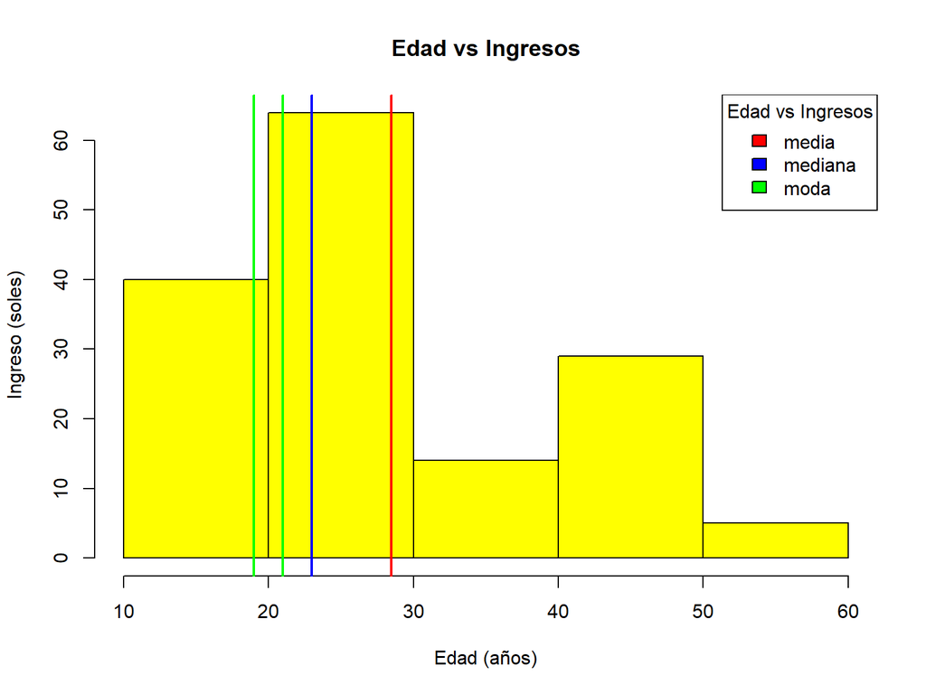

```r
prom_es <- mean(DataFinal$Edad, na.rm = T)
median_es <- median(DataFinal$Edad, na.rm = T)
moda_es <- mfv(DataFinal$Edad, na_rm = T)

hist(DataFinal$Edad, breaks = 5,
     main = "Edad vs Ingresos",
     xlab = "Edad (años)",
     ylab = "Ingreso (soles)",
     col = "yellow")
abline(v = c(prom_es,median_es, moda_es), col = c("red","blue","green", "green"), lwd = 2)
legend(x = "topright",
       legend = c("media", "mediana", "moda"),
        fill = c("red","blue", "green"),
        title = "Edad vs Ingresos")
```

```r
library(fitdistrplus)
```

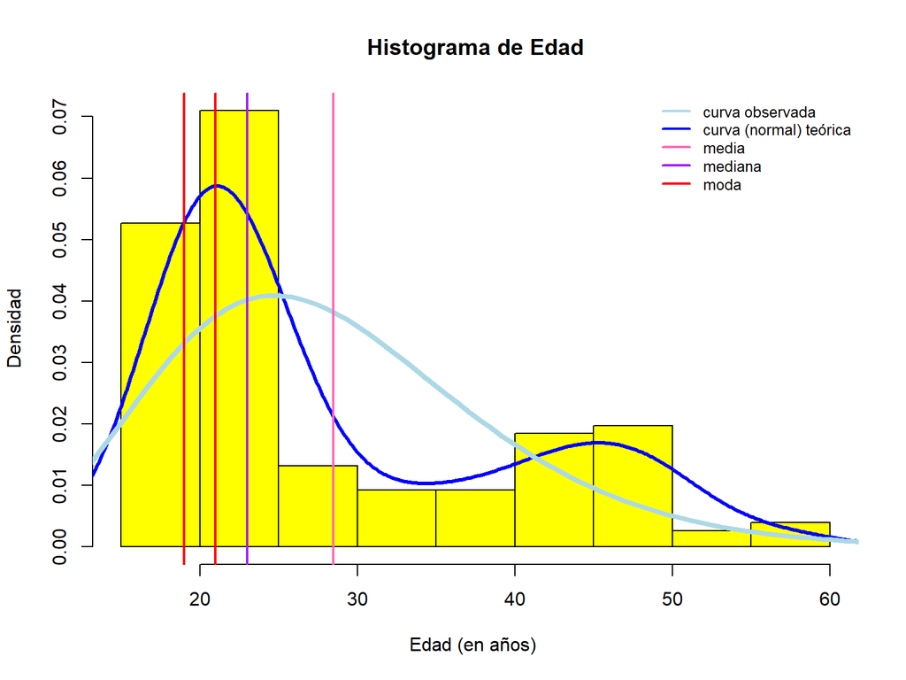

```r
library(survival)
x <- DataFinal$Edad
dx<- density(x)
model<-fitdist(x, "gamma")
a=model$estimate[1]
b=model$estimate[2]
h<-hist(DataFinal$Edad,breaks=10, freq=F, main="Histograma de Edad", ylab = "Densidad" ,xlab="Edad (en años) ", col="yellow")
lines(dx, lwd = 3, col = "blue")
curve(dgamma(x,a,b),from=0,to=70,col="lightblue",lwd=4,add=T)
abline(v = c(prom_es,median_es, moda_es), col = c("hotpink", "purple","red", "red"), lwd = 2)
legend("topright", c("curva observada", "curva (normal) teórica", "media", "mediana", "moda"),
       lty = 1, lwd = 2, col = c("lightblue", "blue","hotpink", "purple", "red", "red"), bty = "n",
       cex = 0.8)
```

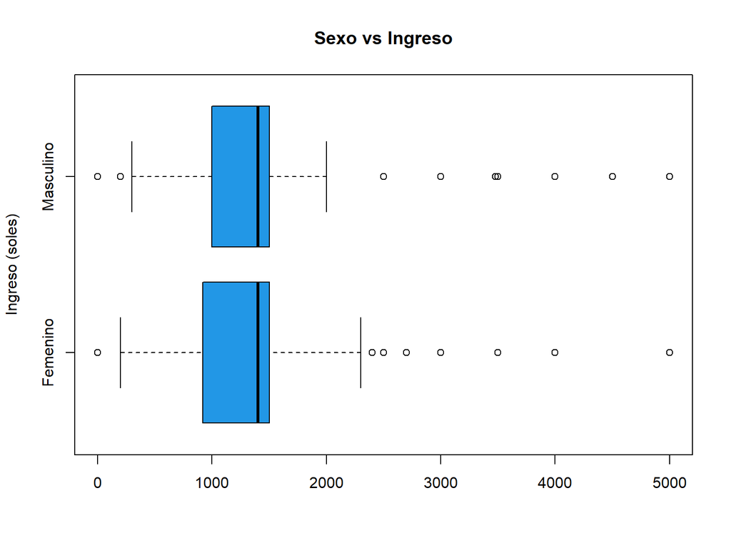

```r
boxplot(DataFinal$Ingresos ~ DataFinal$Sexo, col = 4,
        main = "Sexo vs Ingreso", horizontal = T,
     xlab = "",
     ylab = "Ingreso (soles)")
```

# Diferencias de ideologías según el sexo

### ¿Un hombre que se queda en casa para cuidar a los niños es menos hombre?

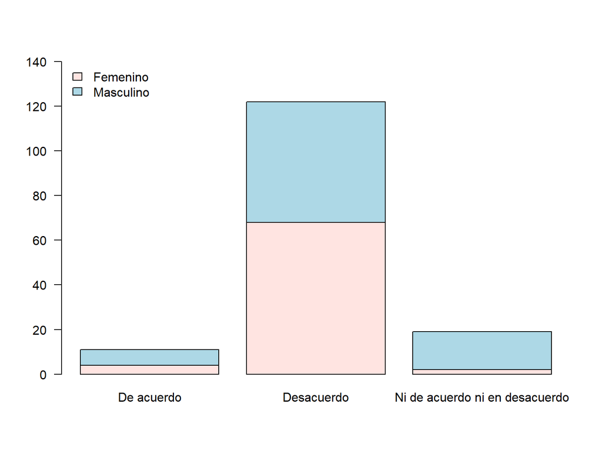

```r
tabla <- table(DataFinal$Sexo, DataFinal$HombrecuidaHijos)
barplot(tabla, beside = F, las=1,
        xlab='', ylab='',
        col = c("mistyrose", "lightblue"),
        ylim = c(0, 140))
legend('topleft', legend=rownames(tabla), bty='n',
       fill=c("mistyrose", "lightblue"))
```

### Me incomodaría si mi jefe fuera mujer

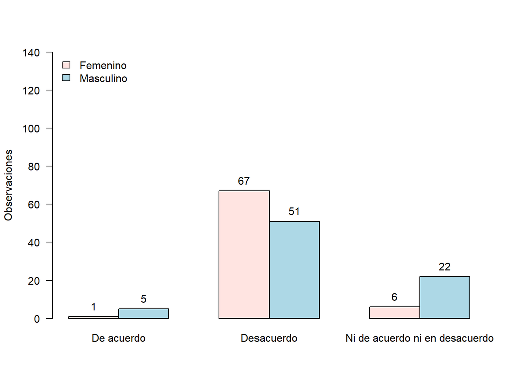

```r
tabla <- table(DataFinal$Sexo, DataFinal$JefeMujer)
xx <- barplot(tabla, beside = T, las=1,
        xlab='', ylab='Observaciones',
        col = c("mistyrose", "lightblue"),
        ylim = c(0, 140))
legend('topleft', legend=rownames(tabla), bty='n',
       fill=c("mistyrose", "lightblue"))
text(x=xx, y=tabla, pos=3, cex=1, col="black",
     label=round(tabla, 4))
```

### ¿Hay más ventajas siendo hombres o mujeres?

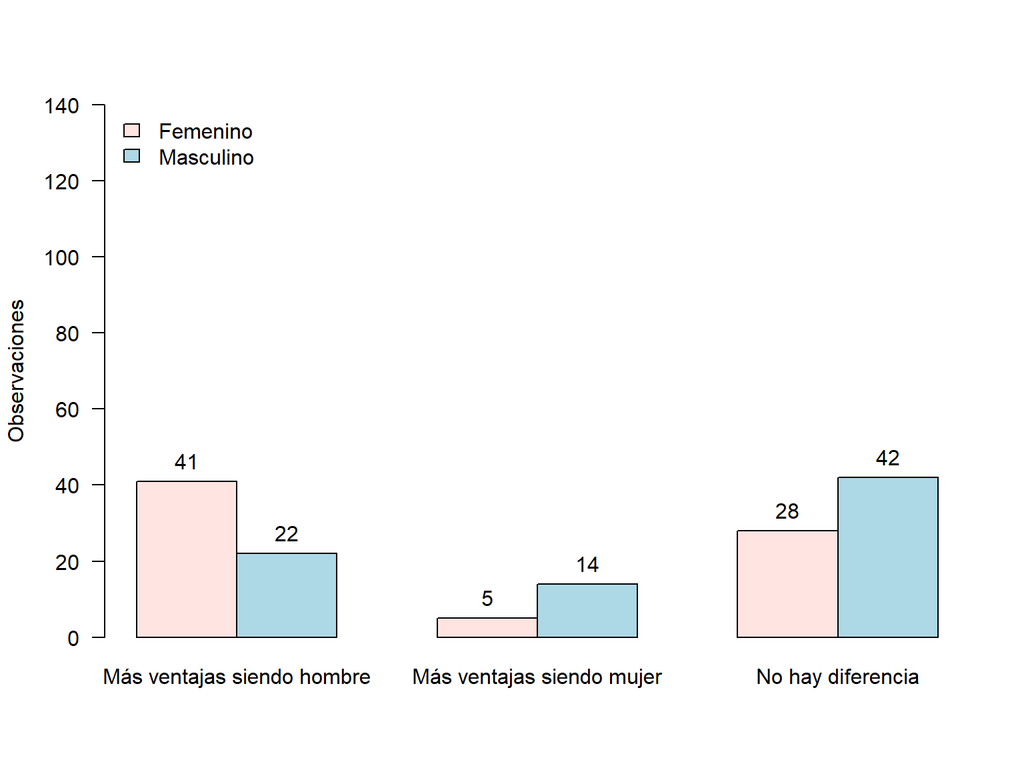

```r
tabla <- table(DataFinal$Sexo, DataFinal$PreferenciaSexo)
xx <- barplot(tabla, beside = T, las=1,
        xlab='', ylab='Observaciones',
        col = c("mistyrose", "lightblue"),
        ylim = c(0, 140))
legend('topleft', legend=rownames(tabla), bty='n',
       fill=c("mistyrose", "lightblue"))
text(x=xx, y=tabla, pos=3, cex=1, col="black",
     label=round(tabla, 4))
```

### Las mujeres no lograrán el cambio a menos que los hombres ayuden

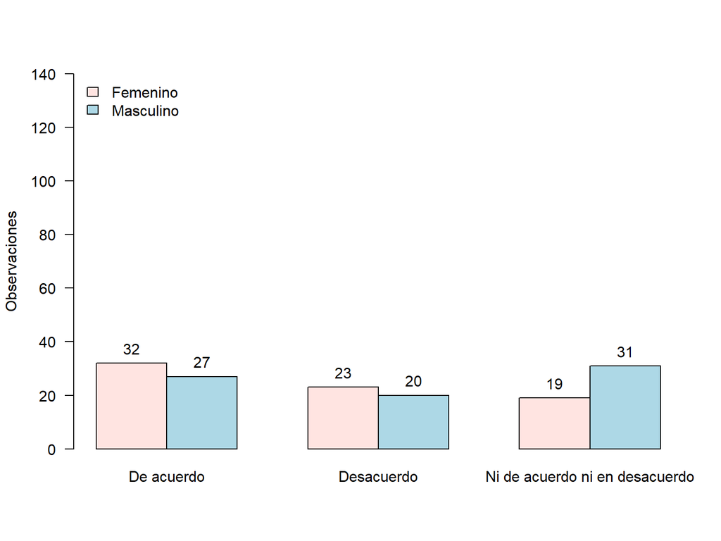

```r
tabla <- table(DataFinal$Sexo, DataFinal$MujerSinIgualdad)
xx <- barplot(tabla, beside = T, las=1,
        xlab='', ylab='Observaciones',
        col = c("mistyrose", "lightblue"),
        ylim = c(0, 140))
legend('topleft', legend=rownames(tabla), bty='n',
       fill=c("mistyrose", "lightblue"))
text(x=xx, y=tabla, pos=3, cex=1, col="black",
     label=round(tabla, 4))
```

### ¿Crees que las mujeres de ahora viven mejor que sus madres y abuelas?

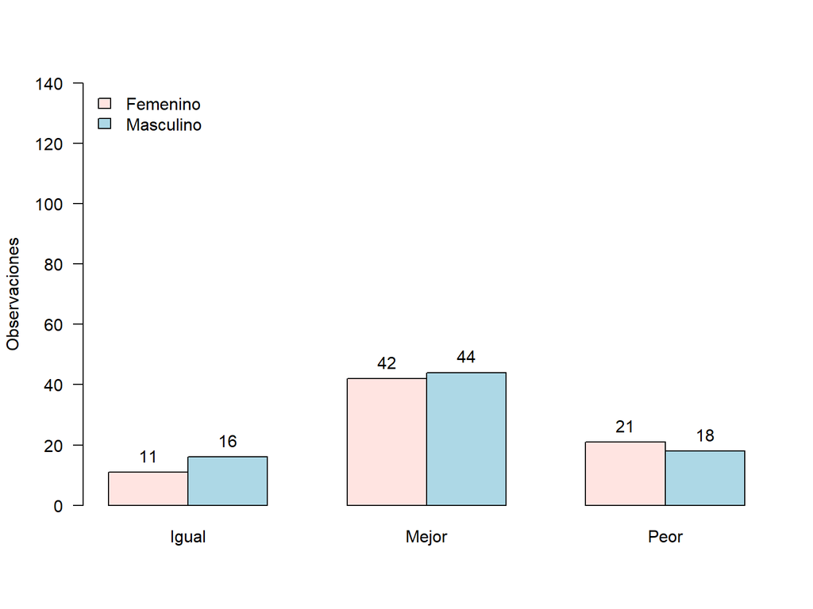

```r
tabla <- table(DataFinal$Sexo, DataFinal$EstiloVida)
xx <- barplot(tabla, beside = T, las=1,
        xlab='', ylab='Observaciones',
        col = c("mistyrose", "lightblue"),
        ylim = c(0, 140))
legend('topleft', legend=rownames(tabla), bty='n',
       fill=c("mistyrose", "lightblue"))
text(x=xx, y=tabla, pos=3, cex=1, col="black",
     label=round(tabla, 4))
```

# Ingresos vs Grado de instrucción

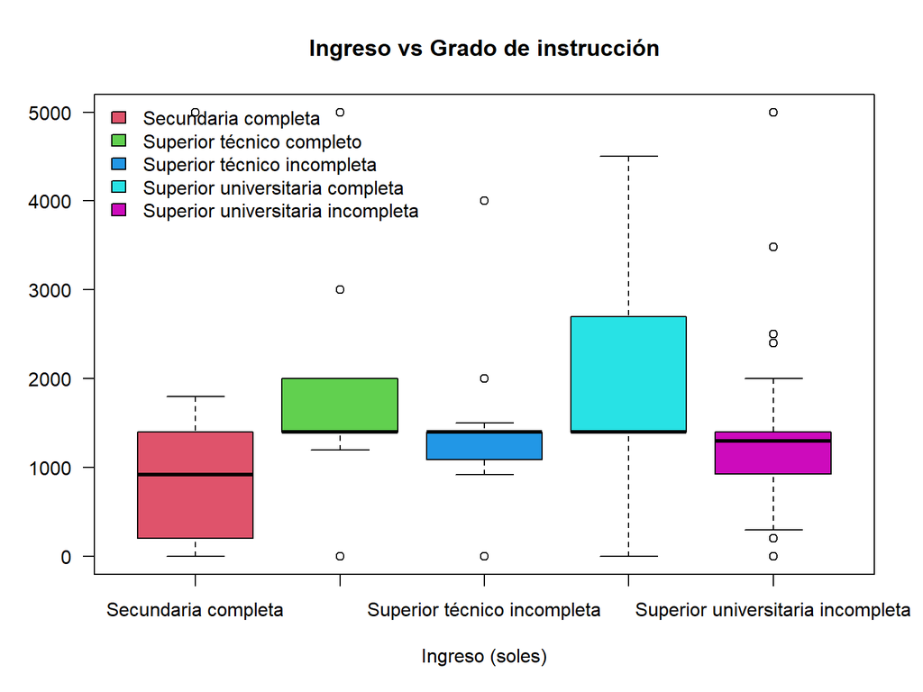

```r
tabla <- table(DataFinal$Instruccion, DataFinal$Ingresos)
boxplot(DataFinal$Ingresos ~ DataFinal$Instruccion, col = c(2,3,4,5,6), las=1,
        main = "Ingreso vs Grado de instrucción", horizontal = F,
     xlab = "Ingreso (soles)",
     ylab = "")
legend('topleft', legend=rownames(tabla), bty='n',
       fill=c(2,3,4,5,6))
```

# Sexo vs los 6 ámbitos de apoyo

### ¿Cuanto cree que se apoya a la mujer en el ámbito del negocio?

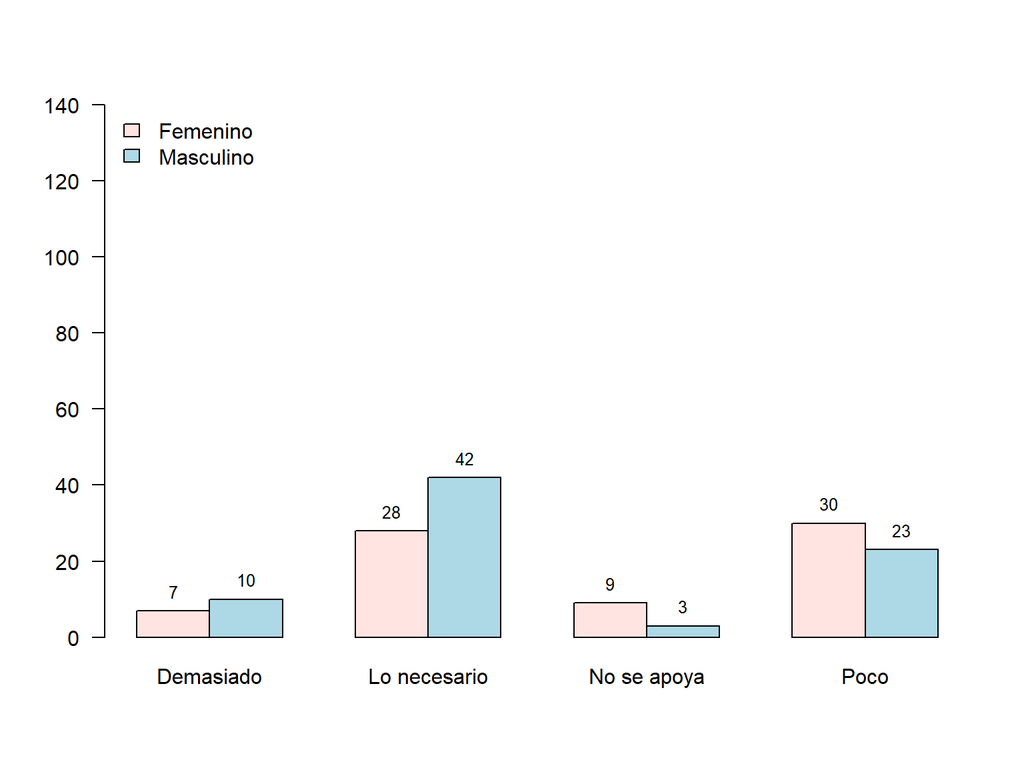

```r
tabla <- table(DataFinal$Sexo, DataFinal$igualnegocio)
xx <-barplot(tabla, beside = T, las=1,
        xlab='', ylab='',
        col = c("mistyrose", "lightblue"),
        ylim = c(0, 140))
legend('topleft', legend=rownames(tabla), bty='n',
       fill=c("mistyrose", "lightblue"))
text(x=xx, y=tabla, pos=3, cex=0.8, col="black",
     label=round(tabla, 4))
```

### ¿Cuánto cree que se apoya a la mujer en el ámbito del deporte?

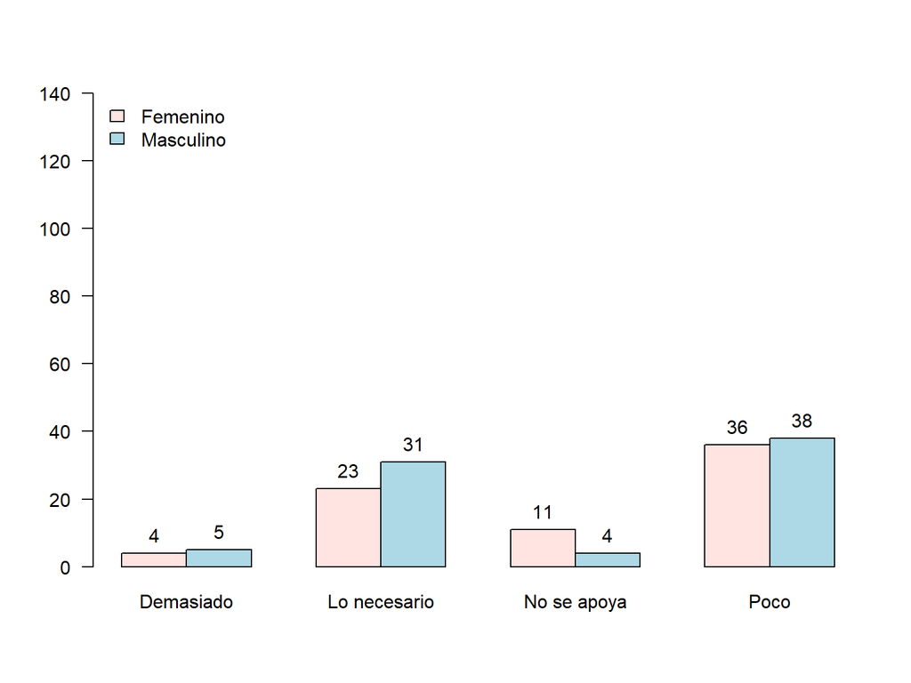

```r
tabla <- table(DataFinal$Sexo, DataFinal$igualdeporte)
xx <- barplot(tabla, beside = T, las=1,
        xlab='', ylab='',
        col = c("mistyrose", "lightblue"),
        ylim = c(0, 140))
legend('topleft', legend=rownames(tabla), bty='n',
       fill=c("mistyrose", "lightblue"))
text(x=xx, y=tabla, pos=3, cex=1, col="black",
     label=round(tabla, 4))
```

### ¿Cuánto cree que se apoya a la mujer en los medios de comunicación, incluso la televisión?

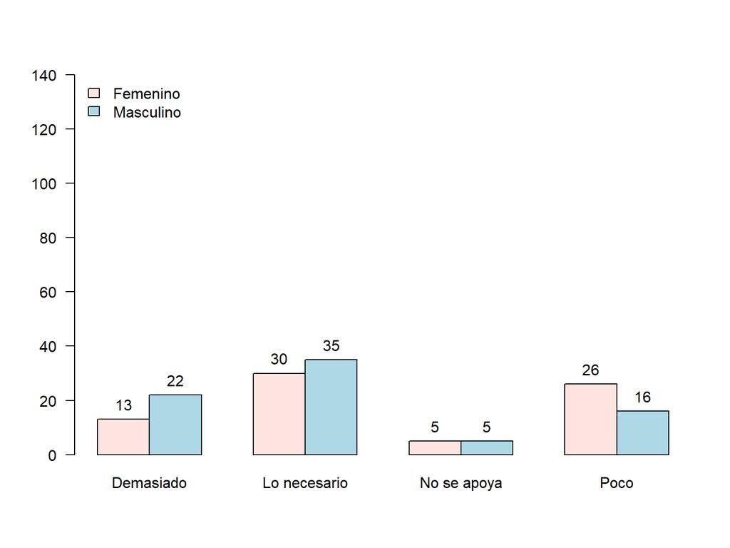

```r
tabla <- table(DataFinal$Sexo, DataFinal$igualtelecomunicaciones)
xx <- barplot(tabla, beside =T, las=1,
        xlab='', ylab='',
        col = c("mistyrose", "lightblue"),
        ylim = c(0, 140))
legend('topleft', legend=rownames(tabla), bty='n',
       fill=c("mistyrose", "lightblue"))
text(x=xx, y=tabla, pos=3, cex=1, col="black",
     label=round(tabla, 4))
```

### ¿Cuánto cree que se apoya a la mujer en el ámbito de la ciencia?

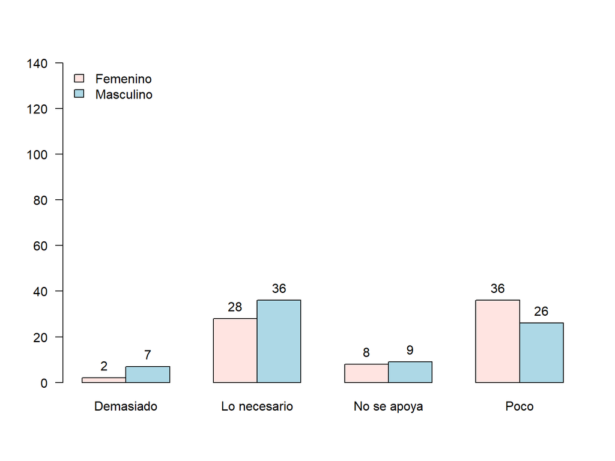

```r
tabla <- table(DataFinal$Sexo, DataFinal$igualciencias)
xx <- barplot(tabla, beside = T, las=1,
        xlab='', ylab='',
        col = c("mistyrose", "lightblue"),
        ylim = c(0, 140))
legend('topleft', legend=rownames(tabla), bty='n',
       fill=c("mistyrose", "lightblue"))
text(x=xx, y=tabla, pos=3, cex=1, col="black",
     label=round(tabla, 4))
```

### ¿Cuánto cree que se apoya a la mujer en el ámbito de la educación?

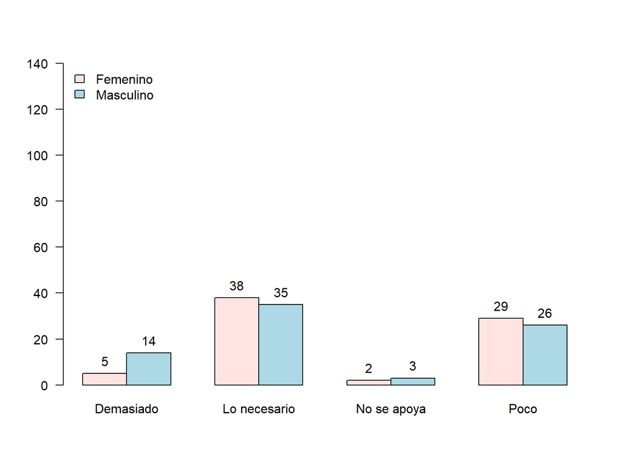

```r
tabla <- table(DataFinal$Sexo, DataFinal$igualeducacion)
xx <- barplot(tabla, beside = T, las=1,
        xlab='', ylab='',
        col = c("mistyrose", "lightblue"),
        ylim = c(0, 140))
legend('topleft', legend=rownames(tabla), bty='n',
       fill=c("mistyrose", "lightblue"))
text(x=xx, y=tabla, pos=3, cex=1, col="black",
     label=round(tabla, 4))
```

### ¿Cuánto cree que se apoya a la mujer en el ámbito del cuidado de los niños?

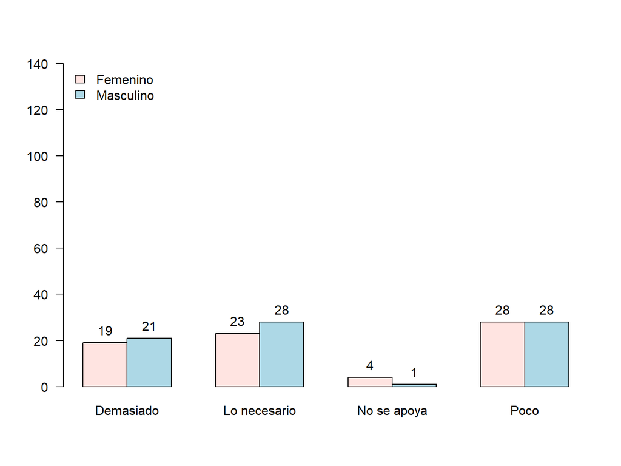

```r
tabla <- table(DataFinal$Sexo, DataFinal$Cuidaninos)
xx <- barplot(tabla, beside = T, las=1,
        xlab='', ylab='',
        col = c("mistyrose", "lightblue"),
        ylim = c(0, 140))
legend('topleft', legend=rownames(tabla), bty='n',
       fill=c("mistyrose", "lightblue"))
text(x=xx, y=tabla, pos=3, cex=1, col="black",
     label=round(tabla, 4))
```

# Análisis probabilístico

*Hallar la probabilidad de que una persona tenga a lo mucho un ingreso de 1200 soles mensuales.*

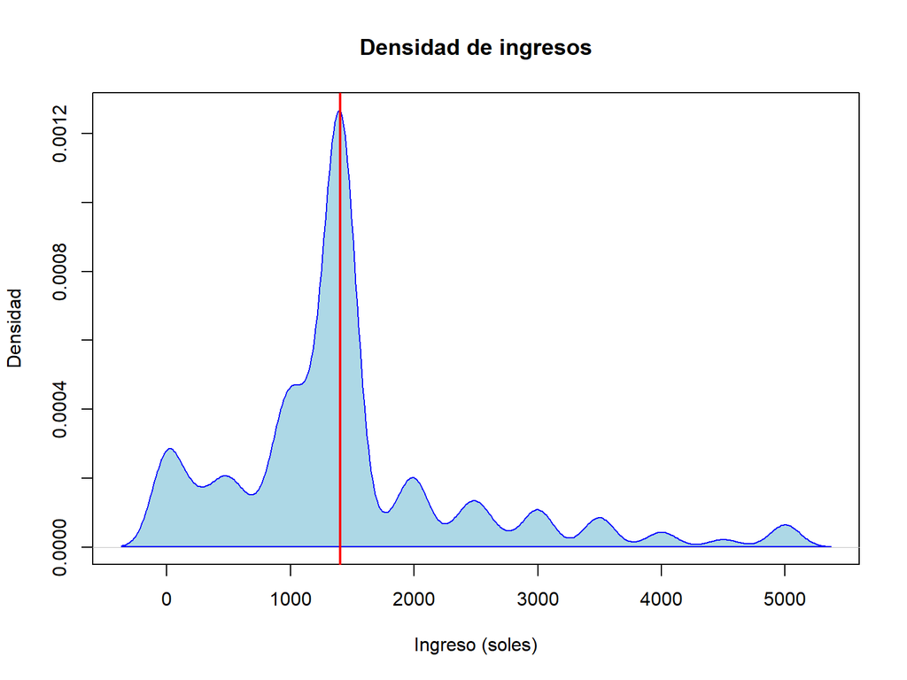

```r
library(modeest)
d <- density(DataFinal$Ingresos, na.rm = T)
moda_es <- mfv(DataFinal$Ingresos, na_rm = T)
plot(d, main="Densidad de ingresos", xlab = "Ingreso (soles)", ylab = "Densidad")
polygon(d, col="lightblue", border="blue", lwd=1)
abline(v = c(moda_es), col = c("red"), lwd = 2)
```

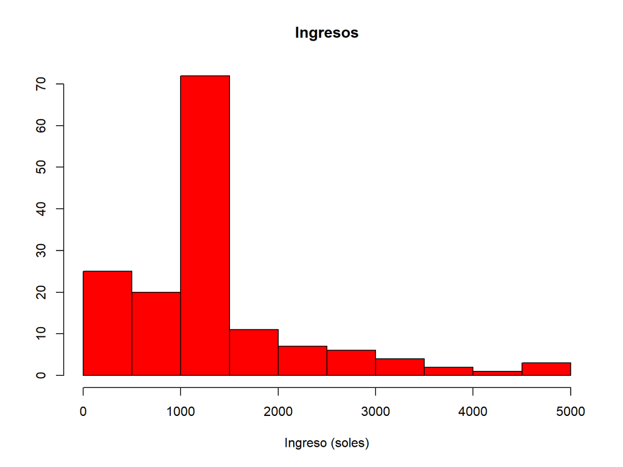

```r
hist(DataFinal$Ingresos, breaks = 12,
     main = "Ingresos",
     xlab = "Ingreso (soles)",
     ylab = "",
     col = "red")
```

```r
c <- c(DataFinal$Ingresos, na.rm=T)
```

variable: Ingreso mensual en soles. std: desviación estándar prom_es: promedio

```r
std <- sd(DataFinal$Ingresos, na.rm = T)
prom_es <- mean(DataFinal$Ingresos, na.rm = T)
round(pnorm(1200, mean = prom_es, sd = std)*100,2)
```

```
## [1] 40.27
```

La probabilidad es de 40.27%